# INN_Learner_Notebook_Full_code_version_FINAL_Amardeep_v05

Bank Churn Prediction

## Problem Statement

### Context

Businesses like banks which provide service have to worry about problem of 'Customer Churn' i.e. customers leaving and joining another service provider. It is important to understand which aspects of the service influence a customer's decision in this regard. Management can concentrate efforts on improvement of service, keeping in mind these priorities.

### Objective

You as a Data scientist with the bank need to build a neural network based classifier that can determine whether a customer will leave the bank or not in the next 6 months.

### Data Dictionary

- CustomerId: Unique ID which is assigned to each customer
- Surname: Last name of the customer
- CreditScore: It defines the credit history of the customer.
- Geography: A customer’s location
- Gender: It defines the Gender of the customer
- Age: Age of the customer
- Tenure: Number of years for which the customer has been with the bank
- NumOfProducts: refers to the number of products that a customer has purchased through the bank.
- Balance: Account balance
- HasCrCard: It is a categorical variable which decides whether the customer has credit card or not.
- EstimatedSalary: Estimated salary
- isActiveMember: Is is a categorical variable which decides whether the customer is active member of the bank or not ( Active member in the sense, using bank products regularly, making transactions etc )
- Exited : whether or not the customer left the bank within six month. It can take two values **0=No ( Customer did not leave the bank )** 1=Yes ( Customer left the bank )

## Importing necessary libraries

```python
# Libraries to help with reading and manipulating data
import pandas as pd
import numpy as np

# libaries to help with data visualization
import matplotlib.pyplot as plt
import seaborn as sns

# Library to split data
from sklearn.model_selection import train_test_split

# library to import to standardize the data
from sklearn.preprocessing import StandardScaler, LabelEncoder,OneHotEncoder

# importing different functions to build models
import tensorflow as tf
from tensorflow import keras
from keras import backend
from keras.models import Sequential
from keras.layers import Dense, Dropout, BatchNormalization

# importing SMOTE
from imblearn.over_sampling import SMOTE

# importing metrics
from sklearn import metrics
from sklearn.metrics import classification_report

from sklearn.metrics import (
    f1_score,
    accuracy_score,
    recall_score,
    precision_score,
    confusion_matrix,
    roc_auc_score,
)

import time  # Module for time-related operations.


import random

# Library to avoid the warnings
import warnings
warnings.filterwarnings("ignore")
```

## Loading the dataset

```python
# import google drive and mount drive
from google.colab import drive
drive.mount('/content/drive/')

df_Load = pd.read_csv("/content/drive/My Drive/Colab Notebooks/Churn.csv")
df = df_Load.copy()
```

## Data Overview

```python
# Review sample data, size, shape and info of the dataset

# 1. view the first 5 rows of the data and  last 5 rows of the data
df.head(5)
```

|  | RowNumber | CustomerId | Surname | CreditScore | Geography | Gender | Age | Tenure | Balance | NumOfProducts | HasCrCard | IsActiveMember | EstimatedSalary | Exited |
| --- | --- | --- | --- | --- | --- | --- | --- | --- | --- | --- | --- | --- | --- | --- |
| 0 | 1 | 15634602 | Hargrave | 619 | France | Female | 42 | 2 | 0.00 | 1 | 1 | 1 | 101348.88 | 1 |
| 1 | 2 | 15647311 | Hill | 608 | Spain | Female | 41 | 1 | 83807.86 | 1 | 0 | 1 | 112542.58 | 0 |
| 2 | 3 | 15619304 | Onio | 502 | France | Female | 42 | 8 | 159660.80 | 3 | 1 | 0 | 113931.57 | 1 |
| 3 | 4 | 15701354 | Boni | 699 | France | Female | 39 | 1 | 0.00 | 2 | 0 | 0 | 93826.63 | 0 |
| 4 | 5 | 15737888 | Mitchell | 850 | Spain | Female | 43 | 2 | 125510.82 | 1 | 1 | 1 | 79084.10 | 0 |

```python
#2. View last rows
df.tail(5)
```

|  | RowNumber | CustomerId | Surname | CreditScore | Geography | Gender | Age | Tenure | Balance | NumOfProducts | HasCrCard | IsActiveMember | EstimatedSalary | Exited |
| --- | --- | --- | --- | --- | --- | --- | --- | --- | --- | --- | --- | --- | --- | --- |
| 9995 | 9996 | 15606229 | Obijiaku | 771 | France | Male | 39 | 5 | 0.00 | 2 | 1 | 0 | 96270.64 | 0 |
| 9996 | 9997 | 15569892 | Johnstone | 516 | France | Male | 35 | 10 | 57369.61 | 1 | 1 | 1 | 101699.77 | 0 |
| 9997 | 9998 | 15584532 | Liu | 709 | France | Female | 36 | 7 | 0.00 | 1 | 0 | 1 | 42085.58 | 1 |
| 9998 | 9999 | 15682355 | Sabbatini | 772 | Germany | Male | 42 | 3 | 75075.31 | 2 | 1 | 0 | 92888.52 | 1 |
| 9999 | 10000 | 15628319 | Walker | 792 | France | Female | 28 | 4 | 130142.79 | 1 | 1 | 0 | 38190.78 | 0 |

```python
#3. View no. of rows and columns
df.shape
```

```
(10000, 14)
```

```python
#4. View details of the columns
print(df.info())

#5. Check missing, unique and duplcate values
# Check missing values
print("\nNumber of missing or null values:\n", df.isna().sum())
# Check unique
print("\nNo.of unique values:\n",df.nunique())
```

```
<class 'pandas.core.frame.DataFrame'>
RangeIndex: 10000 entries, 0 to 9999
Data columns (total 14 columns):
 #   Column           Non-Null Count  Dtype
---  ------           --------------  -----
 0   RowNumber        10000 non-null  int64
 1   CustomerId       10000 non-null  int64
 2   Surname          10000 non-null  object
 3   CreditScore      10000 non-null  int64
 4   Geography        10000 non-null  object
 5   Gender           10000 non-null  object
 6   Age              10000 non-null  int64
 7   Tenure           10000 non-null  int64
 8   Balance          10000 non-null  float64
 9   NumOfProducts    10000 non-null  int64
 10  HasCrCard        10000 non-null  int64
 11  IsActiveMember   10000 non-null  int64
 12  EstimatedSalary  10000 non-null  float64
 13  Exited           10000 non-null  int64
dtypes: float64(2), int64(9), object(3)
memory usage: 1.1+ MB
None

Number of missing or null values:
 RowNumber          0
CustomerId         0
Surname            0
CreditScore        0
Geography          0
Gender             0
Age                0
Tenure             0
Balance            0
NumOfProducts      0
HasCrCard          0
IsActiveMember     0
EstimatedSalary    0
Exited             0
dtype: int64

No.of unique values:
 RowNumber          10000
CustomerId         10000
Surname             2932
CreditScore          460
Geography              3
Gender                 2
Age                   70
Tenure                11
Balance             6382
NumOfProducts          4
HasCrCard              2
IsActiveMember         2
EstimatedSalary     9999
Exited                 2
dtype: int64
```

```python
# 6. Check for duplicate values
df.duplicated().sum()
```

```
0
```

```python
#7. View statistical summary of the dataset
df.describe().T
```

|  | count | mean | std | min | 25% | 50% | 75% | max |
| --- | --- | --- | --- | --- | --- | --- | --- | --- |
| RowNumber | 10000.0 | 5.000500e+03 | 2886.895680 | 1.00 | 2500.75 | 5.000500e+03 | 7.500250e+03 | 10000.00 |
| CustomerId | 10000.0 | 1.569094e+07 | 71936.186123 | 15565701.00 | 15628528.25 | 1.569074e+07 | 1.575323e+07 | 15815690.00 |
| CreditScore | 10000.0 | 6.505288e+02 | 96.653299 | 350.00 | 584.00 | 6.520000e+02 | 7.180000e+02 | 850.00 |
| Age | 10000.0 | 3.892180e+01 | 10.487806 | 18.00 | 32.00 | 3.700000e+01 | 4.400000e+01 | 92.00 |
| Tenure | 10000.0 | 5.012800e+00 | 2.892174 | 0.00 | 3.00 | 5.000000e+00 | 7.000000e+00 | 10.00 |
| Balance | 10000.0 | 7.648589e+04 | 62397.405202 | 0.00 | 0.00 | 9.719854e+04 | 1.276442e+05 | 250898.09 |
| NumOfProducts | 10000.0 | 1.530200e+00 | 0.581654 | 1.00 | 1.00 | 1.000000e+00 | 2.000000e+00 | 4.00 |
| HasCrCard | 10000.0 | 7.055000e-01 | 0.455840 | 0.00 | 0.00 | 1.000000e+00 | 1.000000e+00 | 1.00 |
| IsActiveMember | 10000.0 | 5.151000e-01 | 0.499797 | 0.00 | 0.00 | 1.000000e+00 | 1.000000e+00 | 1.00 |
| EstimatedSalary | 10000.0 | 1.000902e+05 | 57510.492818 | 11.58 | 51002.11 | 1.001939e+05 | 1.493882e+05 | 199992.48 |
| Exited | 10000.0 | 2.037000e-01 | 0.402769 | 0.00 | 0.00 | 0.000000e+00 | 0.000000e+00 | 1.00 |

## Data Clean-Up

```python
#RowNumber , CustomerId and Surname are columns not relevant to the analysis and model building, hence dropping them
df = df.drop(['RowNumber', 'CustomerId', 'Surname'], axis=1)
```

```python
df.info()
```

```
<class 'pandas.core.frame.DataFrame'>
RangeIndex: 10000 entries, 0 to 9999
Data columns (total 11 columns):
 #   Column           Non-Null Count  Dtype
---  ------           --------------  -----
 0   CreditScore      10000 non-null  int64
 1   Geography        10000 non-null  object
 2   Gender           10000 non-null  object
 3   Age              10000 non-null  int64
 4   Tenure           10000 non-null  int64
 5   Balance          10000 non-null  float64
 6   NumOfProducts    10000 non-null  int64
 7   HasCrCard        10000 non-null  int64
 8   IsActiveMember   10000 non-null  int64
 9   EstimatedSalary  10000 non-null  float64
 10  Exited           10000 non-null  int64
dtypes: float64(2), int64(7), object(2)
memory usage: 859.5+ KB
```

```python
# Analyse 'seemingly' wrong values in the 'EstimatedSalary' coulumn since the minimum value showed 11.58 dollars
for i in range(0, 10001, 1000):
  print(f'no. of customer will EstimatedSalary value less than {i} dollars in the dataset:',df['EstimatedSalary'].lt(i).sum())
```

```
no. of customer will EstimatedSalary value less than 0 dollars in the dataset: 0
no. of customer will EstimatedSalary value less than 1000 dollars in the dataset: 59
no. of customer will EstimatedSalary value less than 2000 dollars in the dataset: 107
no. of customer will EstimatedSalary value less than 3000 dollars in the dataset: 154
no. of customer will EstimatedSalary value less than 4000 dollars in the dataset: 213
no. of customer will EstimatedSalary value less than 5000 dollars in the dataset: 264
no. of customer will EstimatedSalary value less than 6000 dollars in the dataset: 311
no. of customer will EstimatedSalary value less than 7000 dollars in the dataset: 358
no. of customer will EstimatedSalary value less than 8000 dollars in the dataset: 397
no. of customer will EstimatedSalary value less than 9000 dollars in the dataset: 447
no. of customer will EstimatedSalary value less than 10000 dollars in the dataset: 508
```

```python
# Due to lack of further information and given we know that mean and meadian for estimated salary are at ~100k,
# we will assume all values below 10k dollars for estimated salary are erroneous and therefore we will delete them.
# Ideally we would have also discussed this step with the client stakeholders to confirm the assumption or fix the values based on additional information from the client
df = df[df['EstimatedSalary'] >= 10000]
df.describe().T
```

|  | count | mean | std | min | 25% | 50% | 75% | max |
| --- | --- | --- | --- | --- | --- | --- | --- | --- |
| CreditScore | 9492.0 | 650.665508 | 96.620311 | 350.00 | 584.00 | 652.000 | 718.0000 | 850.00 |
| Age | 9492.0 | 38.947429 | 10.488946 | 18.00 | 32.00 | 37.000 | 44.0000 | 92.00 |
| Tenure | 9492.0 | 5.030657 | 2.893066 | 0.00 | 3.00 | 5.000 | 8.0000 | 10.00 |
| Balance | 9492.0 | 76822.512356 | 62381.301432 | 0.00 | 0.00 | 97459.580 | 127775.3675 | 250898.09 |
| NumOfProducts | 9492.0 | 1.529182 | 0.581465 | 1.00 | 1.00 | 1.000 | 2.0000 | 4.00 |
| HasCrCard | 9492.0 | 0.707227 | 0.455059 | 0.00 | 0.00 | 1.000 | 1.0000 | 1.00 |
| IsActiveMember | 9492.0 | 0.515276 | 0.499793 | 0.00 | 0.00 | 1.000 | 1.0000 | 1.00 |
| EstimatedSalary | 9492.0 | 105181.472336 | 54531.776005 | 10008.68 | 58317.43 | 104672.285 | 151905.8225 | 199992.48 |
| Exited | 9492.0 | 0.203961 | 0.402962 | 0.00 | 0.00 | 0.000 | 0.0000 | 1.00 |

```python
# The following four columns have categorical data with no ordinal values, therefore convert them into category columns- Geography, Gender, HasCrCard, IsActiveMember
for col in ['Geography', 'Gender', 'HasCrCard', 'IsActiveMember']:
  print(f"{col}: Categories",df[col].unique())
  df[col] = df[col].astype('category')
  print('\n')

# Change values of HarCrCarf and IsActiveMember to 'yes' and 'no'
df['HasCrCard'] = df['HasCrCard'].replace({0:'no', 1:'yes'})

df['IsActiveMember'] = df['IsActiveMember'].replace({0:'no', 1:'yes'})
```

```
Geography: Categories ['France' 'Spain' 'Germany']


Gender: Categories ['Female' 'Male']


HasCrCard: Categories [1 0]


IsActiveMember: Categories [1 0]
```

## Exploratory Data Analysis

### Utility functions for Univariate Analysis

```python
# Following are utility functions that will be used
# function to plot a boxplot and a histogram along the same scale.

def histogram_boxplot(data, feature, figsize=(5, 3), kde=False, bins=None):
    """
    Boxplot and histogram combined

    data: dataframe
    feature: dataframe column
    figsize: size of figure (default (12,7))
    kde: whether to the show density curve (default False)
    bins: number of bins for histogram (default None)
    """
    f2, (ax_box2, ax_hist2) = plt.subplots(
        nrows=2,  # Number of rows of the subplot grid= 2
        sharex=True,  # x-axis will be shared among all subplots
        gridspec_kw={"height_ratios": (0.25, 0.75)},
        figsize=figsize,
    )  # creating the 2 subplots
    sns.boxplot(
        data=data, x=feature, ax=ax_box2, showmeans=True, color="violet"
    )  # boxplot will be created and a triangle will indicate the mean value of the column
    sns.histplot(
        data=data, x=feature, kde=kde, ax=ax_hist2, bins=bins, palette="winter"
    ) if bins else sns.histplot(
        data=data, x=feature, kde=kde, ax=ax_hist2
    )  # For histogram
    ax_hist2.axvline(
        data[feature].mean(), color="green", linestyle="--"
    )  # Add mean to the histogram
    ax_hist2.axvline(
        data[feature].median(), color="black", linestyle="-"
    )  # Add median to the histogram

#==============================================================

# function to create labeled barplots
def labeled_barplot(data, feature, perc=False, n=None):
    """
    Barplot with percentage at the top

    data: dataframe
    feature: dataframe column
    perc: whether to display percentages instead of count (default is False)
    n: displays the top n category levels (default is None, i.e., display all levels)
    """

    total = len(data[feature])  # length of the column
    count = data[feature].nunique()
    if n is None:
        plt.figure(figsize=(count + 1, 5))
    else:
        plt.figure(figsize=(n + 1, 5))

    plt.xticks(rotation=90, fontsize=10)
    ax = sns.countplot(
        data=data,
        x=feature,
        palette="Paired",
        order=data[feature].value_counts().index[:n].sort_values(),
    )

    for p in ax.patches:
        if perc == True:
            label = "{:.1f}%".format(
                100 * p.get_height() / total
            )  # percentage of each class of the category
        else:
            label = p.get_height()  # count of each level of the category

        x = p.get_x() + p.get_width() / 2  # width of the plot
        y = p.get_height()  # height of the plot

        ax.annotate(
            label,
            (x, y),
            ha="center",
            va="center",
            size=10,
            xytext=(0, 5),
            textcoords="offset points",
        )  # annotate the percentage
    # Get the current figure and change its sizes
    fig = plt.gcf()
    fig.set_figwidth(3)
    fig.set_figheight(5)
    plt.tight_layout()

    plt.show()  # show the plot
```

### Univariate Analysis

(All observations wrt univariate analysis are captured in a consolidated manner at the end of the section **below**)

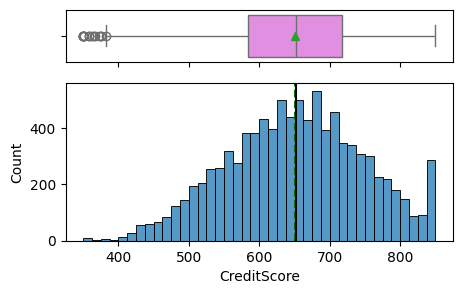

```python
# CreditScore
histogram_boxplot(df,'CreditScore')
```

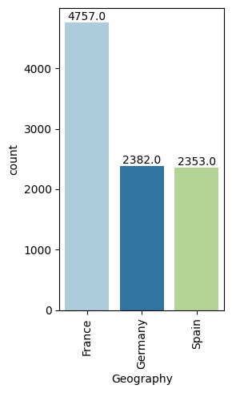

```python
#  Geography
labeled_barplot(df,'Geography')
```

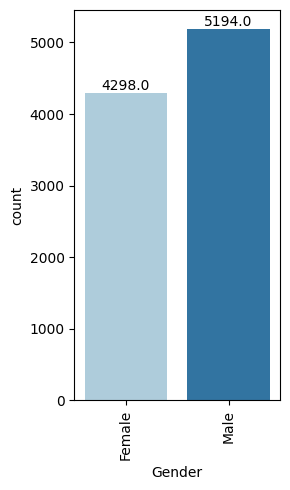

```
Male      0.547198
Female    0.452802
Name: Gender, dtype: float64
```

```python
#  Gender
labeled_barplot(df,'Gender')
df['Gender'].value_counts(normalize = True)
```

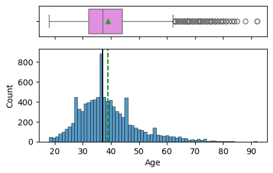

```python
#  Age
histogram_boxplot(df,'Age')
```

```
2     10.377160
1     10.313949
8     10.292878
7     10.282343
5     10.166456
3     10.008428
9      9.934682
4      9.829330
6      9.745048
10     4.962073
0      4.087653
Name: Tenure, dtype: float64
```

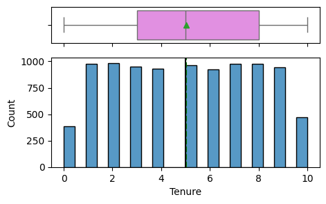

```python
#  Tenure
histogram_boxplot(df,'Tenure')
df['Tenure'].value_counts(normalize= True)*100
```

```
Number of accounts with Balance of Zero $: 3409
```

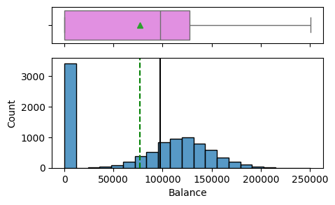

```python
#  Balance
histogram_boxplot(df,'Balance')
print('Number of accounts with Balance of Zero $:', df['Balance'].value_counts()[0])
```

```
Percentage of ownership of no. of products:
 1    50.927097
2    45.828066
3     2.644332
4     0.600506
Name: NumOfProducts, dtype: float64
```

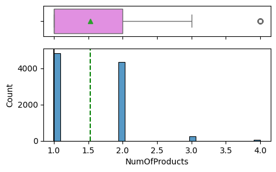

```python
#  NumOfProducts
histogram_boxplot(df,'NumOfProducts')
print('Percentage of ownership of no. of products:\n',df['NumOfProducts'].value_counts(normalize = True)*100)
```

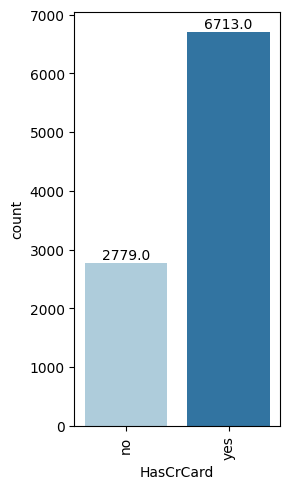

```
Percentage of customer having credit card:
 yes    70.722714
no     29.277286
Name: HasCrCard, dtype: float64
```

```python
#  HasCrCard
labeled_barplot(df,'HasCrCard')
print('Percentage of customer having credit card:\n',df['HasCrCard'].value_counts(normalize = True)*100)
```

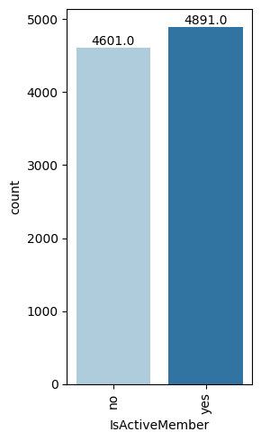

```
Percentage of customers being active members :
 yes    51.527602
no     48.472398
Name: IsActiveMember, dtype: float64
```

```python
#  IsActiveMember
labeled_barplot(df,'IsActiveMember')
print('Percentage of customers being active members :\n',df['IsActiveMember'].value_counts(normalize = True)*100)
```

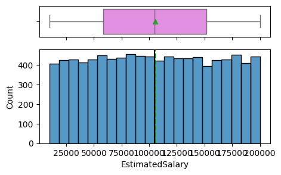

```python
#  EstimatedSalary
histogram_boxplot(df,'EstimatedSalary')
```

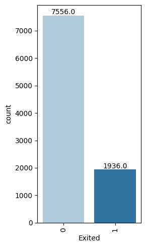

```
0    0.796039
1    0.203961
Name: Exited, dtype: float64
```

```python
#  Exited
labeled_barplot(df,'Exited')
df.Exited.value_counts(normalize = True)
```

### Observations of Univariate Analysis

Observations:

- Credit Scrore - Normal distribution with minimal skewness
- Geography - Customers from france represent ~50% of the data. Germany and Spain are ~25% each
- Gender - ~54% are Male customers
- Age - Right skewed with mean at ~39 and median at 37
- Tenure - Mostly uniform distribution ( except at extremes of 0 and 10 years) with mean/median at 5 years
- Balance - Left skewed with mean at ~76k vs median at ~97k. More than 34% of customers have zero dollar balance in their accounts
- NumOfProducts - ~50% customer have 1 product, 45% have 2 products
- HasCrCard - 70.7% customer have creditcard
- IsActiveMember - 51.5% customer are active members
- EstimatedSalary - Uniform distribution. There are some 'seemingly' wrong values here because the minimum shows 11.58 dollars and this was fixed in the earlier section
- Exited - 20.39% customer have exited in the dataset

### Utility functions for Bivariate Analysis:

```python
# Utility functions below - 1. function to plot stacked bar chart ; 2. function to plot distribution of numerical variable vs target variable
def stacked_barplot(data, predictor, target):
    """
    Print the category counts and plot a stacked bar chart

    data: dataframe
    predictor: independent variable
    target: target variable
    """
    count = data[predictor].nunique()
    sorter = data[target].value_counts().index[-1]
    tab1 = pd.crosstab(data[predictor], data[target], margins=True,normalize='index')#.sort_values(by=sorter, ascending=False)
    print(tab1)
    print("-" * 100)
    tab = pd.crosstab(data[predictor], data[target], normalize="index").sort_values(
        by=sorter, ascending=False
    )
    tab.plot(kind="bar", stacked=True, figsize=(count + 1, 5))
    plt.legend(
        loc="lower left", frameon=False,
    )
    plt.legend(loc="upper left", bbox_to_anchor=(1, 1))
    fig = plt.gcf()
    fig.set_figwidth(1.5)
    fig.set_figheight(3)
    plt.show()

#===================================
### Function to plot distributions
def distribution_plot_wrt_target(data, predictor, target):

    fig, axs = plt.subplots(2, 2, figsize=(8, 5))

    target_uniq = data[target].unique()

    axs[0, 0].set_title("Distribution of target for target=" + str(target_uniq[0]))
    sns.histplot(
        data=data[data[target] == target_uniq[0]],
        x=predictor,
        kde=True,
        ax=axs[0, 0],
        color="teal",
    )

    axs[0, 1].set_title("Distribution of target for target=" + str(target_uniq[1]))
    sns.histplot(
        data=data[data[target] == target_uniq[1]],
        x=predictor,
        kde=True,
        ax=axs[0, 1],
        color="orange",
    )

    axs[1, 0].set_title("Boxplot w.r.t target")
    sns.boxplot(data=data, x=target, y=predictor, ax=axs[1, 0], palette="gist_rainbow")

    axs[1, 1].set_title("Boxplot (without outliers) w.r.t target")
    sns.boxplot(
        data=data,
        x=target,
        y=predictor,
        ax=axs[1, 1],
        showfliers=False,
        palette="gist_rainbow",
    )

    plt.tight_layout()
    plt.show()
```

### Bivariate Analysis

#### Correlation plot

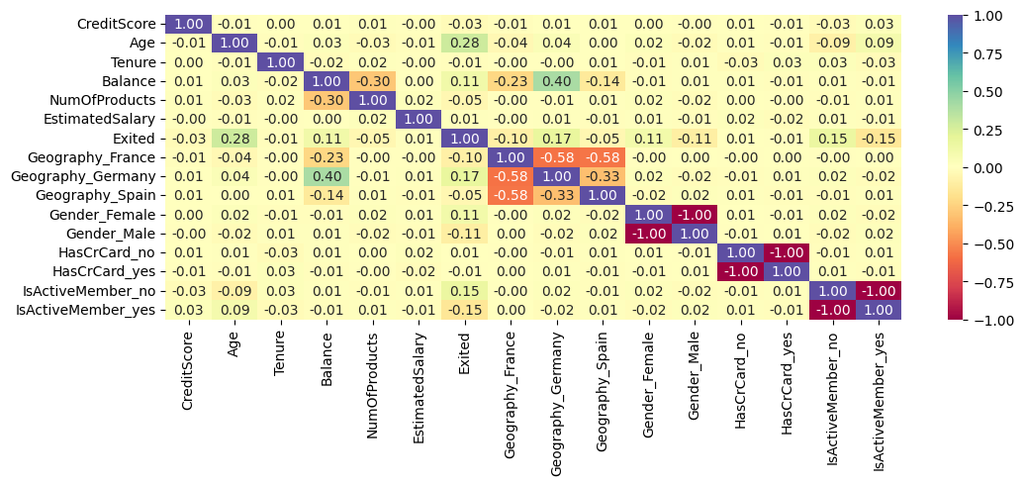

```python
#create a headmap to study/cross-validate relationships
#quickly select columns of interest aswell as pre-process the category columns using one-hot encoding
df_select_cols_for_heatmap = df.copy()
df_select_cols_for_heatmap = pd.get_dummies(df_select_cols_for_heatmap) # dont drop any column in get dummies because we want to evaluate all the columns for their corr with target column
plt.figure(figsize=(12, 4))
sns.heatmap(df_select_cols_for_heatmap.corr(), annot=True, vmin=-1, vmax=1, fmt=".2f", cmap="Spectral")
plt.show()
```

#### Analyze relationship of target variable with categorical variables

```
Exited            0         1
Geography
France     0.836241  0.163759
Germany    0.679261  0.320739
Spain      0.832979  0.167021
All        0.796039  0.203961
----------------------------------------------------------------------------------------------------
```

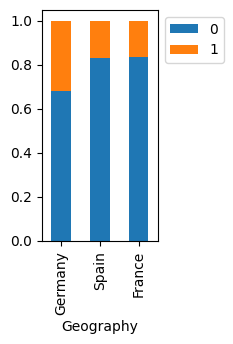

```
Exited         0         1
Gender
Female  0.748953  0.251047
Male    0.835002  0.164998
All     0.796039  0.203961
----------------------------------------------------------------------------------------------------
```

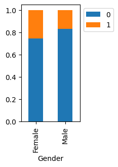

```
Exited            0         1
HasCrCard
no         0.792731  0.207269
yes        0.797408  0.202592
All        0.796039  0.203961
----------------------------------------------------------------------------------------------------
```

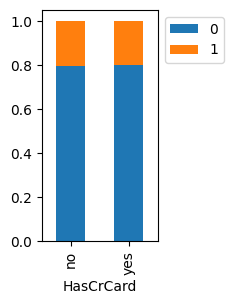

```
Exited                 0         1
IsActiveMember
no              0.731797  0.268203
yes             0.856471  0.143529
All             0.796039  0.203961
----------------------------------------------------------------------------------------------------
```

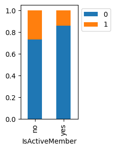

```python
# Study the relationship between the target varaible (ie Exited ) and the other categorial variables
for col in ['Geography', 'Gender', 'HasCrCard', 'IsActiveMember','Exited']:
  if(col != 'Exited'):
    stacked_barplot(df, col, 'Exited')
```

#### Analyze relationship of target variable with numerical variables

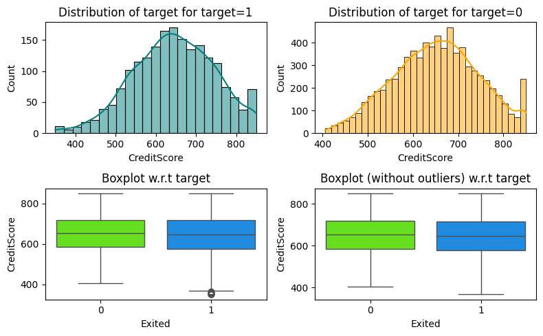

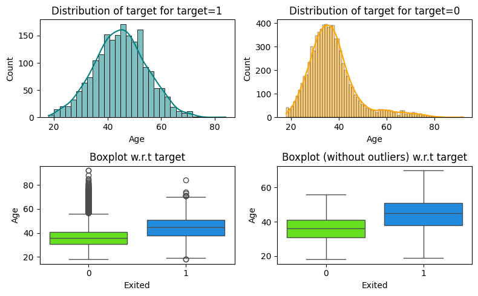

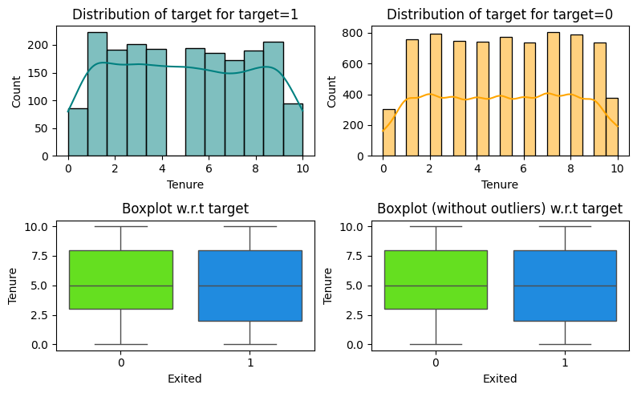

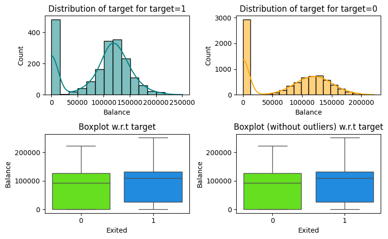

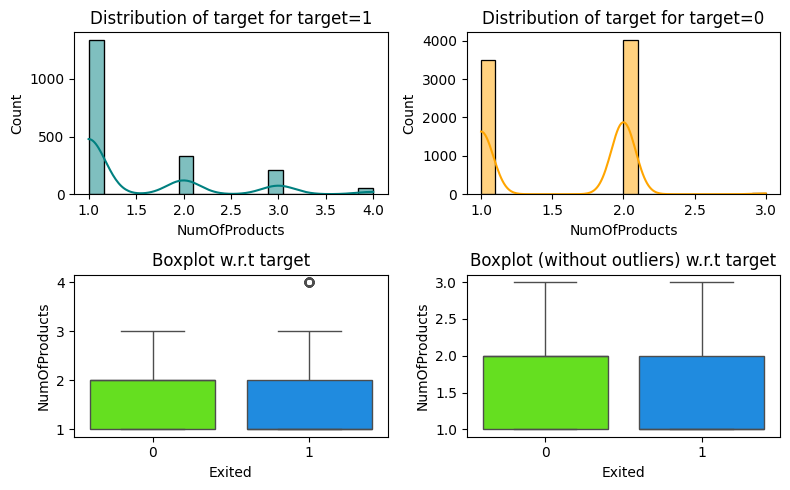

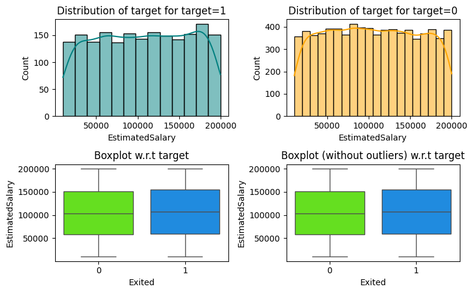

```python
# study the relationship between target variable and the numerical variables
# Filter for the columns of interest to begin with
select_cols = df.select_dtypes(include=['int64','float64']).columns.tolist()

df_num_cols = df[select_cols].copy()

# draw the graphs
for i in df_num_cols.columns.to_list():
  if(i != 'Exited'):
    distribution_plot_wrt_target(df_num_cols, i, 'Exited')
```

## Data Preprocessing

We will preprocess the dataset in this section to get it ready for model building. Preprocessing will include:

- Splitting Train, test and validation datasets
- We would have done missing value imputation ( post splitting to avoid data leaks) here but since there are no missing values, we will skip this step
- Dummy variable creation ie use pd.get_dummies
- Scale the data

### Train-validation-test Split

```python
# 1.Split the df data set into train, validation and test sets in the proportion of 60%, 20% and 20% respectively

X = df.drop(['Exited'],axis=1) # seperete out the target variable from the independed variables
y = df['Exited'] # Exited

# Split the dataset into Training+Val(temp) and Testing sets.
X_temp, X_test, y_temp, y_test = train_test_split(X, y, test_size=0.2, random_state=42, stratify=y)

# then we split the temporary set into train and validation
X_train, X_val, y_train, y_val = train_test_split(X_temp, y_temp, test_size=0.25, random_state=42, stratify=y_temp)

# Check the shapes so everything is in order
print('df shape:',df.shape)

print('X train:',X_train.shape,'Y train shape',y_train.shape)
print('X val shape:',X_val.shape,'Y val shape',y_val.shape)
print('X test shape:',X_test.shape,'Y test shape',y_test.shape)
```

```
df shape: (9492, 11)
X train: (5694, 10) Y train shape (5694,)
X val shape: (1899, 10) Y val shape (1899,)
X test shape: (1899, 10) Y test shape (1899,)
```

### Dummy Variable Creation

```python
# Encoding categorical X variables
#'Geography', 'Gender', 'HasCrCard', 'IsActiveMember'
X_train = pd.get_dummies(X_train, columns=["Geography","Gender","HasCrCard","IsActiveMember"],drop_first=True)
X_val = pd.get_dummies(X_val, columns=["Geography","Gender","HasCrCard","IsActiveMember"],drop_first=True)
X_test = pd.get_dummies(X_test, columns=["Geography","Gender","HasCrCard","IsActiveMember"],drop_first=True)

print('X_train shape',X_train.shape)
print('X_val shape',X_val.shape)
print('X_test shape',X_test.shape)
```

```
X_train shape (5694, 11)
X_val shape (1899, 11)
X_test shape (1899, 11)
```

### Data Normalization

```python
#Since all the numerical values are on different scales,  we will be scaling them to bring them to the same scale.
# list columns to normalize
cols_list = ["CreditScore","Age","Tenure","Balance","EstimatedSalary"]

# creating an instance of the standard scaler
sc = StandardScaler()

#scale the selected numerical columns
X_train[cols_list] = sc.fit_transform(X_train[cols_list])
X_val[cols_list] = sc.transform(X_val[cols_list]) # use the mean and var of the train set to scale the val and test sets aswell so there is no data leakage
X_test[cols_list] = sc.transform(X_test[cols_list])

print('X_train head',X_train.head(5))
print('X_val head',X_val.head(5))
print('X_test head',X_test.head(5))
```

```
X_train head       CreditScore       Age    Tenure   Balance  NumOfProducts  \
480      1.422959 -0.471339  0.337919  1.284225              1
9528     0.916263 -0.471339  1.379103 -1.230921              1
3891     0.750811 -1.037502 -0.009143  0.246842              1
1146    -0.376329 -0.848781 -0.703266  0.880235              2
695      0.140708  1.698954  0.337919 -1.230921              2

      EstimatedSalary  Geography_Germany  Geography_Spain  Gender_Male  \
480          1.378165                  0                1            1
9528        -0.815819                  0                0            1
3891         0.692117                  1                0            0
1146        -0.921463                  1                0            0
695         -1.639484                  0                0            1

      HasCrCard_yes  IsActiveMember_yes
```

[output cut: 45 more lines]

## Model Building

### Model Evaluation Criterion

The logic for choosing the metric that would be the best metric for this business scenario is as follows:

- Model can make wrong predictions as in :
  - Model predicts a customer will exit but the customer doesn't exit (ie False Positive)
  - Model predicts a customer to not exit but the customer infact exits (ie False Negative)

Predicting a customer to not exit but infact the customer doest exit is more critical & expensive i.e. it is essencially losing a valuable customer or asset. We will therefore need to reduce False Negatives. Therefore the bank would want 'Recall' to be maximized given greater the Recall higher the chances of minimizing false negatives. Hence, the focus while building the model will be on increasing the metric 'Recall'.

### Utility function to get the performance score and confusion matrix scores of a model

```python
#Define a function that returns model performance metrics and confusion matrix in a form of two lists.
#We will call this function every time we 'fit' a model, to check for its performance and get its metrics and scores

def Get_model_Performace_metrics_and_confusion_matrix(model,X_df,y_df):
  #1. First,get the performance metrics scores
  y_prediction = model.predict(X_df) #predict 'y' using the X data set to being with ; let y_prediction be =1 for predictions >0.5
  y_prediction = (y_prediction > 0.5)
  acc = accuracy_score(y_df, y_prediction)  # get Accuracy metrics
  recall = recall_score(y_df, y_prediction)  # get Recall metrics
  precision = precision_score(y_df, y_prediction)  # get Precision metricx
  f1 = f1_score(y_df, y_prediction)  # get F1-score

  #2 Second, get the confusion matrix
  cm = confusion_matrix(y_df, y_prediction).flatten(order='C') #  values as [tn, fp, fn, tp];  tn: true negative count, fp: false positive count, fn: false negative count, and tp:true positive count

  return [acc,recall,precision,f1], list(cm) # return the two lists
```

### Neural Network with SGD Optimizer

```python
# Clear the current Keras session, resetting all layers and models previously created, freeing up memory and resources.
tf.keras.backend.clear_session()

#Fix the seed for random number generators so that we can ensure we receive the same output everytime
np.random.seed(42)
random.seed(42)
tf.random.set_seed(42)
```

```python
#Initializing the neural network
model_0 = Sequential()
# Adding a hidden layer with 64 neurons and relu as activation function
model_0.add(Dense(64, activation='relu', input_dim = X_train.shape[1]))
# Add another hidden layer
model_0.add(Dense(32, activation='relu'))
# Add the output layer with the number of neurons required.
model_0.add(Dense(1, activation = 'sigmoid'))
```

Now that we are done with the model architecture, we will compile the model.

In the compilation function we will provide the loss function that we want to optimize, the corresponding optimization algorithm, and the evaluation metric that we are interested in for evaluating the model -

- Since this is a binary classification task, we will be minimizing the binary_crossentropy loss function
- We will instanciate the sgd optimization algorithm to begin with
- Also since we want to use RECALL metric we will pass that as the metrics of interest aswell

```python
# define loss function
loss_fuc = 'binary_crossentropy'

#create an instance of the SGD optimizer class and pass it to the compile() method of the Keras model
optimizer_sgd = tf.keras.optimizers.SGD(learning_rate=0.0005)

# Select the relavent metrics of interest
metric_R = keras.metrics.Recall() # select this as our metric of interest as explained above # Other potential metrics: metric = 'accuracy';  metric = keras.metrics.Precision();  metric = keras.metrics.F1Score()
```

```python
# compile the model with all our selections
model_0.compile(loss = loss_fuc, optimizer = optimizer_sgd, metrics=metric_R)
model_0.summary()
```

```
Model: "sequential"
_________________________________________________________________
 Layer (type)                Output Shape              Param #
=================================================================
 dense (Dense)               (None, 64)                768

 dense_1 (Dense)             (None, 32)                2080

 dense_2 (Dense)             (None, 1)                 33

=================================================================
Total params: 2881 (11.25 KB)
Trainable params: 2881 (11.25 KB)
Non-trainable params: 0 (0.00 Byte)
_________________________________________________________________
```

We will fit the model now to training and validation data sets. We will begin with a batch size of 32 and 100 epochs. (lower epoch of 50 was tried out offine but the recall value was fairly low, hence demonstrated baseline model with 100 epochs to begin with below)

```python
#define batch size and epochs
batch_size = 32
epochs = 100

#Fit the base neural network on the train anf validation sets
start = time.time()
history_0 = model_0.fit(X_train, y_train, validation_data=(X_val,y_val) , batch_size=batch_size, epochs=epochs, verbose=2)
end = time.time()
```

```
178/178 - 3s - loss: 0.6274 - recall: 0.1317 - val_loss: 0.6130 - val_recall: 0.0827 - 3s/epoch - 18ms/step
178/178 - 1s - loss: 0.6020 - recall: 0.0404 - val_loss: 0.5906 - val_recall: 0.0233 - 1s/epoch - 6ms/step
178/178 - 1s - loss: 0.5817 - recall: 0.0086 - val_loss: 0.5727 - val_recall: 0.0078 - 1s/epoch - 7ms/step
178/178 - 1s - loss: 0.5653 - recall: 0.0017 - val_loss: 0.5582 - val_recall: 0.0000e+00 - 1s/epoch - 8ms/step
178/178 - 1s - loss: 0.5521 - recall: 0.0000e+00 - val_loss: 0.5466 - val_recall: 0.0000e+00 - 1s/epoch - 7ms/step
178/178 - 2s - loss: 0.5412 - recall: 0.0000e+00 - val_loss: 0.5370 - val_recall: 0.0000e+00 - 2s/epoch - 11ms/step
178/178 - 1s - loss: 0.5324 - recall: 0.0000e+00 - val_loss: 0.5292 - val_recall: 0.0000e+00 - 1s/epoch - 6ms/step
178/178 - 1s - loss: 0.5251 - recall: 0.0000e+00 - val_loss: 0.5227 - val_recall: 0.0000e+00 - 874ms/epoch - 5ms/step
178/178 - 1s - loss: 0.5190 - recall: 0.0000e+00 - val_loss: 0.5174 - val_recall: 0.0000e+00 - 1s/epoch - 6ms/step
178/178 - 1s - loss: 0.5139 - recall: 0.0000e+00 - val_loss: 0.5128 - val_recall: 0.0000e+00 - 923ms/epoch - 5ms/step
178/178 - 1s - loss: 0.5096 - recall: 0.0000e+00 - val_loss: 0.5090 - val_recall: 0.0000e+00 - 1s/epoch - 6ms/step
178/178 - 1s - loss: 0.5059 - recall: 0.0000e+00 - val_loss: 0.5056 - val_recall: 0.0000e+00 - 1s/epoch - 6ms/step
178/178 - 1s - loss: 0.5027 - recall: 0.0000e+00 - val_loss: 0.5027 - val_recall: 0.0000e+00 - 921ms/epoch - 5ms/step
178/178 - 1s - loss: 0.4999 - recall: 0.0000e+00 - val_loss: 0.5002 - val_recall: 0.0000e+00 - 824ms/epoch - 5ms/step
178/178 - 1s - loss: 0.4974 - recall: 0.0000e+00 - val_loss: 0.4978 - val_recall: 0.0000e+00 - 1s/epoch - 6ms/step
178/178 - 1s - loss: 0.4951 - recall: 0.0000e+00 - val_loss: 0.4957 - val_recall: 0.0000e+00 - 1s/epoch - 6ms/step
178/178 - 2s - loss: 0.4931 - recall: 0.0000e+00 - val_loss: 0.4938 - val_recall: 0.0000e+00 - 2s/epoch - 11ms/step
178/178 - 2s - loss: 0.4911 - recall: 0.0000e+00 - val_loss: 0.4920 - val_recall: 0.0000e+00 - 2s/epoch - 12ms/step
178/178 - 1s - loss: 0.4893 - recall: 0.0000e+00 - val_loss: 0.4903 - val_recall: 0.0000e+00 - 1s/epoch - 6ms/step
178/178 - 1s - loss: 0.4877 - recall: 0.0000e+00 - val_loss: 0.4887 - val_recall: 0.0000e+00 - 805ms/epoch - 5ms/step
178/178 - 1s - loss: 0.4861 - recall: 0.0000e+00 - val_loss: 0.4872 - val_recall: 0.0000e+00 - 1s/epoch - 6ms/step
178/178 - 1s - loss: 0.4846 - recall: 0.0000e+00 - val_loss: 0.4857 - val_recall: 0.0000e+00 - 1s/epoch - 7ms/step
178/178 - 1s - loss: 0.4832 - recall: 0.0000e+00 - val_loss: 0.4843 - val_recall: 0.0000e+00 - 660ms/epoch - 4ms/step
178/178 - 1s - loss: 0.4818 - recall: 0.0000e+00 - val_loss: 0.4830 - val_recall: 0.0000e+00 - 958ms/epoch - 5ms/step
178/178 - 1s - loss: 0.4805 - recall: 0.0000e+00 - val_loss: 0.4817 - val_recall: 0.0000e+00 - 1s/epoch - 6ms/step
178/178 - 1s - loss: 0.4792 - recall: 0.0000e+00 - val_loss: 0.4804 - val_recall: 0.0000e+00 - 1s/epoch - 7ms/step
178/178 - 1s - loss: 0.4779 - recall: 0.0000e+00 - val_loss: 0.4792 - val_recall: 0.0000e+00 - 1s/epoch - 6ms/step
178/178 - 1s - loss: 0.4767 - recall: 0.0000e+00 - val_loss: 0.4780 - val_recall: 0.0000e+00 - 1s/epoch - 6ms/step
178/178 - 1s - loss: 0.4756 - recall: 0.0000e+00 - val_loss: 0.4769 - val_recall: 0.0000e+00 - 1s/epoch - 6ms/step
178/178 - 2s - loss: 0.4744 - recall: 0.0000e+00 - val_loss: 0.4758 - val_recall: 0.0000e+00 - 2s/epoch - 10ms/step
178/178 - 1s - loss: 0.4733 - recall: 0.0000e+00 - val_loss: 0.4747 - val_recall: 0.0000e+00 - 1s/epoch - 8ms/step
178/178 - 1s - loss: 0.4722 - recall: 0.0000e+00 - val_loss: 0.4736 - val_recall: 0.0000e+00 - 1s/epoch - 7ms/step
178/178 - 1s - loss: 0.4712 - recall: 0.0000e+00 - val_loss: 0.4726 - val_recall: 0.0000e+00 - 948ms/epoch - 5ms/step
178/178 - 0s - loss: 0.4702 - recall: 0.0000e+00 - val_loss: 0.4715 - val_recall: 0.0000e+00 - 423ms/epoch - 2ms/step
178/178 - 0s - loss: 0.4691 - recall: 0.0000e+00 - val_loss: 0.4705 - val_recall: 0.0000e+00 - 462ms/epoch - 3ms/step
178/178 - 0s - loss: 0.4682 - recall: 0.0000e+00 - val_loss: 0.4696 - val_recall: 0.0000e+00 - 408ms/epoch - 2ms/step
178/178 - 0s - loss: 0.4672 - recall: 0.0000e+00 - val_loss: 0.4686 - val_recall: 0.0000e+00 - 437ms/epoch - 2ms/step
178/178 - 0s - loss: 0.4663 - recall: 0.0000e+00 - val_loss: 0.4677 - val_recall: 0.0000e+00 - 406ms/epoch - 2ms/step
178/178 - 0s - loss: 0.4654 - recall: 0.0000e+00 - val_loss: 0.4668 - val_recall: 0.0000e+00 - 442ms/epoch - 2ms/step
178/178 - 0s - loss: 0.4645 - recall: 0.0000e+00 - val_loss: 0.4659 - val_recall: 0.0000e+00 - 452ms/epoch - 3ms/step
```

[output cut: 45 more lines]

```
178/178 - 0s - loss: 0.4383 - recall: 0.0465 - val_loss: 0.4397 - val_recall: 0.0362 - 384ms/epoch - 2ms/step
178/178 - 0s - loss: 0.4380 - recall: 0.0482 - val_loss: 0.4393 - val_recall: 0.0362 - 393ms/epoch - 2ms/step
178/178 - 0s - loss: 0.4377 - recall: 0.0491 - val_loss: 0.4390 - val_recall: 0.0388 - 467ms/epoch - 3ms/step
178/178 - 0s - loss: 0.4373 - recall: 0.0508 - val_loss: 0.4387 - val_recall: 0.0388 - 407ms/epoch - 2ms/step
178/178 - 1s - loss: 0.4370 - recall: 0.0516 - val_loss: 0.4383 - val_recall: 0.0388 - 512ms/epoch - 3ms/step
178/178 - 0s - loss: 0.4367 - recall: 0.0534 - val_loss: 0.4380 - val_recall: 0.0413 - 441ms/epoch - 2ms/step
178/178 - 0s - loss: 0.4364 - recall: 0.0577 - val_loss: 0.4377 - val_recall: 0.0413 - 415ms/epoch - 2ms/step
178/178 - 0s - loss: 0.4361 - recall: 0.0602 - val_loss: 0.4374 - val_recall: 0.0413 - 465ms/epoch - 3ms/step
178/178 - 0s - loss: 0.4358 - recall: 0.0611 - val_loss: 0.4371 - val_recall: 0.0439 - 461ms/epoch - 3ms/step
178/178 - 0s - loss: 0.4355 - recall: 0.0611 - val_loss: 0.4368 - val_recall: 0.0465 - 385ms/epoch - 2ms/step
178/178 - 0s - loss: 0.4352 - recall: 0.0654 - val_loss: 0.4365 - val_recall: 0.0491 - 370ms/epoch - 2ms/step
178/178 - 0s - loss: 0.4349 - recall: 0.0671 - val_loss: 0.4362 - val_recall: 0.0543 - 403ms/epoch - 2ms/step
178/178 - 0s - loss: 0.4346 - recall: 0.0706 - val_loss: 0.4359 - val_recall: 0.0543 - 436ms/epoch - 2ms/step
178/178 - 0s - loss: 0.4344 - recall: 0.0723 - val_loss: 0.4356 - val_recall: 0.0646 - 434ms/epoch - 2ms/step
178/178 - 1s - loss: 0.4341 - recall: 0.0723 - val_loss: 0.4353 - val_recall: 0.0646 - 1s/epoch - 6ms/step
```

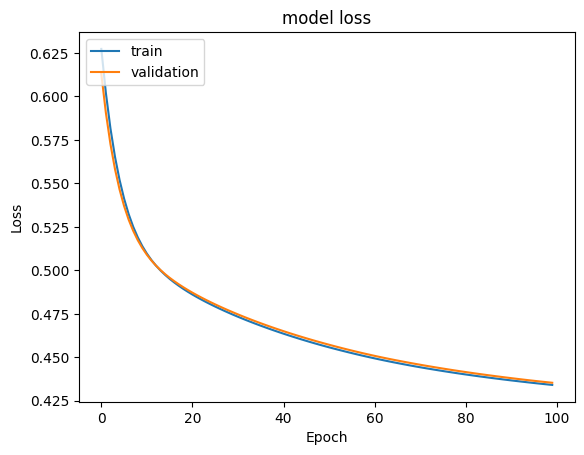

```python
#Plot Train Loss vs Validation Loss
plt.plot(history_0.history['loss'])
plt.plot(history_0.history['val_loss'])
plt.title('model loss')
plt.ylabel('Loss')
plt.xlabel('Epoch')
plt.legend(['train', 'validation'], loc='upper left')
plt.show()
```

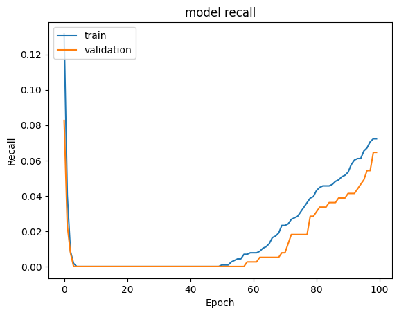

```python
#Plotting Train recall vs Validation recall
plt.plot(history_0.history['recall'])
plt.plot(history_0.history['val_recall'])
plt.title('model recall')
plt.ylabel('Recall')
plt.xlabel('Epoch')
plt.legend(['train', 'validation'], loc='upper left')
plt.show()
```

```python
#Call the  utility function to get performance metrics and confusion matrix for the baseline model on its training and val sets
#p_scores will hold all the performance scores ie Acc, Recall, Precision, F1
#cm_score will hold all the confusion matrix scores ie TN, FP, FN, TP

p_scores_model_0_train, cm_scores_model_0_train = Get_model_Performace_metrics_and_confusion_matrix(model_0,X_train,y_train)
p_scores_model_0_val, cm_scores_model_0_val = Get_model_Performace_metrics_and_confusion_matrix(model_0,X_val,y_val)
```

```python
# Round the values in p_scores_model_0_train,cm_scores_model_0_train,p_scores_model_0_val, cm_scores_model_0_val to 2 decimal places
p_scores_model_0_train = [round(x,2) for x in p_scores_model_0_train]
cm_scores_model_0_train = [round(x,2) for x in cm_scores_model_0_train]
p_scores_model_0_val = [round(x,2) for x in p_scores_model_0_val]
cm_scores_model_0_val = [round(x,2) for x in cm_scores_model_0_val]
```

```python
#Let's create a blank dataframe that will store all the performace scores,confusion matrix cores and all the other hyperparameter sets for all the models we build.
results_df = pd.DataFrame(columns=["Model No.","Model Name","# of hidden layers","No. of neurons in hidden layers","Activation func",
                                   "No. of epochs","Batch size","Train loss","Val loss",
                                   "Train performance score [Acc, Recall, Precision, F1]", "Val  performance score [Acc, Recall, Precision, F1]",
                                   "Train confusion matrix [TN, FP, FN, TP]","Val confusion matrix [TN, FP, FN, TP]","FN %-Train set","FN %-Val set","Time Taken (secs)"])
```

```python
# save all the details of model 0 in the results dataframe
results_df.loc[0] = [0,"NN with SGD",2,"[64, 32]",'relu',
                    100,32,history_0.history["loss"][-1],history_0.history["val_loss"][-1],
                    p_scores_model_0_train,p_scores_model_0_val,cm_scores_model_0_train,cm_scores_model_0_val,
                     cm_scores_model_0_train[2]*100/sum(cm_scores_model_0_train),cm_scores_model_0_val[2]*100/sum(cm_scores_model_0_val),
                     round(end-start,2)]
results_df
```

|  | Model No. | Model Name | # of hidden layers | No. of neurons in hidden layers | Activation func | No. of epochs | Batch size | Train loss | Val loss | Train performance score [Acc, Recall, Precision, F1] | Val performance score [Acc, Recall, Precision, F1] | Train confusion matrix [TN, FP, FN, TP] | Val confusion matrix [TN, FP, FN, TP] | FN %-Train set | FN %-Val set | Time Taken (secs) |
| --- | --- | --- | --- | --- | --- | --- | --- | --- | --- | --- | --- | --- | --- | --- | --- | --- |
| 0 | 0 | NN with SGD | 2 | [64, 32] | relu | 100 | 32 | 0.434101 | 0.435346 | [0.8, 0.08, 0.61, 0.13] | [0.8, 0.06, 0.53, 0.12] | [4476, 56, 1074, 88] | [1490, 22, 362, 25] | 18.86196 | 19.062665 | 83.6 |

```python
# FN percentage value for val set
cm_scores_model_0_val[2]/sum(cm_scores_model_0_val)
```

```
0.19062664560294892
```

Observations on NN with SGD:

- As we can see, the NN is fairly basic with a recall score of 0.06 for the validation set. We will try to improve/optimize the model further in the following steps.

## Model Performance Improvement

### Neural Network with Adam Optimizer

```python
# Clear the current Keras session, resetting all layers and model previously created, freeing up memory and resources.
tf.keras.backend.clear_session()
# Fix the seed for random number generators so that we can ensure we receive the same output everytime
np.random.seed(42)
random.seed(42)
tf.random.set_seed(42)
```

```python
#Initializing the neural network
model_1 = Sequential()
model_1.add(Dense(64,activation='relu',input_dim = X_train.shape[1]))
model_1.add(Dense(32,activation='relu'))
model_1.add(Dense(1, activation = 'sigmoid'))
```

```python
# Use Adam as the optimizer.
optimizer_adam = tf.keras.optimizers.Adam(learning_rate=0.001)
# define recall as metric to be used for optimization
metric_R = keras.metrics.Recall()
# define loss function
loss_fuc = 'binary_crossentropy'

# compile the model with all our selections
model_1.compile(loss = loss_fuc, optimizer = optimizer_adam, metrics=metric_R)
model_1.summary()
```

```
Model: "sequential"
_________________________________________________________________
 Layer (type)                Output Shape              Param #
=================================================================
 dense (Dense)               (None, 64)                768

 dense_1 (Dense)             (None, 32)                2080

 dense_2 (Dense)             (None, 1)                 33

=================================================================
Total params: 2881 (11.25 KB)
Trainable params: 2881 (11.25 KB)
Non-trainable params: 0 (0.00 Byte)
_________________________________________________________________
```

```python
# Train the model

#retain the same batch size and epochs as earlier
batch_size = 32
epochs = 100

#Fit the neural network on the train and validation sets
start = time.time()
history_1 = model_1.fit(X_train, y_train, validation_data=(X_val,y_val) , batch_size=batch_size, epochs=epochs, verbose=2)
end = time.time()
```

```
178/178 - 2s - loss: 0.4565 - recall: 0.0697 - val_loss: 0.4241 - val_recall: 0.1964 - 2s/epoch - 9ms/step
178/178 - 1s - loss: 0.4170 - recall: 0.2410 - val_loss: 0.4138 - val_recall: 0.3359 - 533ms/epoch - 3ms/step
178/178 - 0s - loss: 0.4046 - recall: 0.2995 - val_loss: 0.4109 - val_recall: 0.2300 - 435ms/epoch - 2ms/step
178/178 - 0s - loss: 0.3947 - recall: 0.3305 - val_loss: 0.3998 - val_recall: 0.3411 - 442ms/epoch - 2ms/step
178/178 - 1s - loss: 0.3850 - recall: 0.3640 - val_loss: 0.3921 - val_recall: 0.3876 - 669ms/epoch - 4ms/step
178/178 - 1s - loss: 0.3778 - recall: 0.3563 - val_loss: 0.3949 - val_recall: 0.4522 - 770ms/epoch - 4ms/step
178/178 - 1s - loss: 0.3702 - recall: 0.3916 - val_loss: 0.3838 - val_recall: 0.4134 - 709ms/epoch - 4ms/step
178/178 - 1s - loss: 0.3619 - recall: 0.4105 - val_loss: 0.3879 - val_recall: 0.5116 - 734ms/epoch - 4ms/step
178/178 - 1s - loss: 0.3577 - recall: 0.4251 - val_loss: 0.3797 - val_recall: 0.4548 - 982ms/epoch - 6ms/step
178/178 - 1s - loss: 0.3510 - recall: 0.4303 - val_loss: 0.3697 - val_recall: 0.4419 - 574ms/epoch - 3ms/step
178/178 - 0s - loss: 0.3446 - recall: 0.4423 - val_loss: 0.3724 - val_recall: 0.4703 - 473ms/epoch - 3ms/step
178/178 - 0s - loss: 0.3429 - recall: 0.4621 - val_loss: 0.3707 - val_recall: 0.4935 - 478ms/epoch - 3ms/step
178/178 - 0s - loss: 0.3364 - recall: 0.4682 - val_loss: 0.3695 - val_recall: 0.4212 - 457ms/epoch - 3ms/step
178/178 - 1s - loss: 0.3338 - recall: 0.4682 - val_loss: 0.3685 - val_recall: 0.4444 - 526ms/epoch - 3ms/step
178/178 - 1s - loss: 0.3296 - recall: 0.4811 - val_loss: 0.3640 - val_recall: 0.4574 - 501ms/epoch - 3ms/step
178/178 - 1s - loss: 0.3272 - recall: 0.4897 - val_loss: 0.3635 - val_recall: 0.4961 - 524ms/epoch - 3ms/step
178/178 - 1s - loss: 0.3223 - recall: 0.4888 - val_loss: 0.3664 - val_recall: 0.3979 - 539ms/epoch - 3ms/step
178/178 - 1s - loss: 0.3207 - recall: 0.5000 - val_loss: 0.3603 - val_recall: 0.4444 - 544ms/epoch - 3ms/step
178/178 - 0s - loss: 0.3188 - recall: 0.5000 - val_loss: 0.3649 - val_recall: 0.4083 - 470ms/epoch - 3ms/step
178/178 - 0s - loss: 0.3152 - recall: 0.5052 - val_loss: 0.3603 - val_recall: 0.4884 - 442ms/epoch - 2ms/step
178/178 - 0s - loss: 0.3133 - recall: 0.5077 - val_loss: 0.3642 - val_recall: 0.5349 - 474ms/epoch - 3ms/step
178/178 - 0s - loss: 0.3104 - recall: 0.5129 - val_loss: 0.3602 - val_recall: 0.4910 - 466ms/epoch - 3ms/step
178/178 - 0s - loss: 0.3084 - recall: 0.5155 - val_loss: 0.3627 - val_recall: 0.5013 - 475ms/epoch - 3ms/step
178/178 - 0s - loss: 0.3050 - recall: 0.5207 - val_loss: 0.3647 - val_recall: 0.5220 - 448ms/epoch - 3ms/step
178/178 - 0s - loss: 0.3047 - recall: 0.5344 - val_loss: 0.3629 - val_recall: 0.4625 - 429ms/epoch - 2ms/step
178/178 - 0s - loss: 0.3023 - recall: 0.5293 - val_loss: 0.3638 - val_recall: 0.4858 - 437ms/epoch - 2ms/step
178/178 - 1s - loss: 0.3020 - recall: 0.5250 - val_loss: 0.3630 - val_recall: 0.4910 - 516ms/epoch - 3ms/step
178/178 - 0s - loss: 0.3003 - recall: 0.5336 - val_loss: 0.3669 - val_recall: 0.5220 - 472ms/epoch - 3ms/step
178/178 - 0s - loss: 0.2987 - recall: 0.5422 - val_loss: 0.3621 - val_recall: 0.4548 - 437ms/epoch - 2ms/step
178/178 - 1s - loss: 0.2991 - recall: 0.5361 - val_loss: 0.3619 - val_recall: 0.4729 - 531ms/epoch - 3ms/step
178/178 - 1s - loss: 0.2949 - recall: 0.5439 - val_loss: 0.3771 - val_recall: 0.5969 - 719ms/epoch - 4ms/step
178/178 - 1s - loss: 0.2961 - recall: 0.5422 - val_loss: 0.3650 - val_recall: 0.4574 - 868ms/epoch - 5ms/step
178/178 - 1s - loss: 0.2935 - recall: 0.5456 - val_loss: 0.3747 - val_recall: 0.5788 - 826ms/epoch - 5ms/step
178/178 - 1s - loss: 0.2927 - recall: 0.5499 - val_loss: 0.3811 - val_recall: 0.5685 - 752ms/epoch - 4ms/step
178/178 - 1s - loss: 0.2925 - recall: 0.5448 - val_loss: 0.3646 - val_recall: 0.4884 - 534ms/epoch - 3ms/step
178/178 - 1s - loss: 0.2912 - recall: 0.5525 - val_loss: 0.3690 - val_recall: 0.4858 - 510ms/epoch - 3ms/step
178/178 - 0s - loss: 0.2889 - recall: 0.5491 - val_loss: 0.3742 - val_recall: 0.5426 - 491ms/epoch - 3ms/step
178/178 - 1s - loss: 0.2902 - recall: 0.5628 - val_loss: 0.3666 - val_recall: 0.4729 - 503ms/epoch - 3ms/step
178/178 - 1s - loss: 0.2873 - recall: 0.5491 - val_loss: 0.3691 - val_recall: 0.4599 - 515ms/epoch - 3ms/step
178/178 - 1s - loss: 0.2847 - recall: 0.5568 - val_loss: 0.3907 - val_recall: 0.6279 - 524ms/epoch - 3ms/step
```

[output cut: 45 more lines]

```
178/178 - 0s - loss: 0.2477 - recall: 0.6343 - val_loss: 0.4047 - val_recall: 0.4858 - 451ms/epoch - 3ms/step
178/178 - 0s - loss: 0.2485 - recall: 0.6360 - val_loss: 0.4003 - val_recall: 0.5065 - 432ms/epoch - 2ms/step
178/178 - 0s - loss: 0.2479 - recall: 0.6317 - val_loss: 0.4016 - val_recall: 0.5245 - 429ms/epoch - 2ms/step
178/178 - 1s - loss: 0.2465 - recall: 0.6325 - val_loss: 0.3970 - val_recall: 0.5452 - 507ms/epoch - 3ms/step
178/178 - 1s - loss: 0.2458 - recall: 0.6368 - val_loss: 0.4024 - val_recall: 0.5090 - 533ms/epoch - 3ms/step
178/178 - 0s - loss: 0.2461 - recall: 0.6256 - val_loss: 0.4000 - val_recall: 0.4987 - 425ms/epoch - 2ms/step
178/178 - 0s - loss: 0.2439 - recall: 0.6377 - val_loss: 0.4046 - val_recall: 0.4884 - 440ms/epoch - 2ms/step
178/178 - 0s - loss: 0.2462 - recall: 0.6334 - val_loss: 0.4077 - val_recall: 0.5220 - 483ms/epoch - 3ms/step
178/178 - 1s - loss: 0.2453 - recall: 0.6256 - val_loss: 0.4102 - val_recall: 0.5685 - 524ms/epoch - 3ms/step
178/178 - 0s - loss: 0.2405 - recall: 0.6403 - val_loss: 0.4060 - val_recall: 0.5271 - 432ms/epoch - 2ms/step
178/178 - 0s - loss: 0.2414 - recall: 0.6360 - val_loss: 0.4053 - val_recall: 0.5297 - 441ms/epoch - 2ms/step
178/178 - 0s - loss: 0.2428 - recall: 0.6540 - val_loss: 0.4093 - val_recall: 0.5452 - 481ms/epoch - 3ms/step
178/178 - 0s - loss: 0.2400 - recall: 0.6506 - val_loss: 0.4058 - val_recall: 0.5194 - 453ms/epoch - 3ms/step
178/178 - 0s - loss: 0.2392 - recall: 0.6515 - val_loss: 0.4066 - val_recall: 0.5220 - 457ms/epoch - 3ms/step
178/178 - 0s - loss: 0.2393 - recall: 0.6558 - val_loss: 0.4117 - val_recall: 0.5478 - 495ms/epoch - 3ms/step
```